# NorCal Coffee Subscription

Casey Dyer

2024-08-05

## Background Information

The purpose of this project is to find the best price (cost per lb for bulk coffee that is roasted in Northern California, defined by an imaginary line at the furthest south street in Santa Cruz, CA to the Oregon border at the North end, outlined by the Pacific Ocean to the West and the Nevada State Line to the East.) The overall purpose is to purchase coffee in bulk for my family to drink on a daily basis, but the coffee needs to be of excellent quality, so we will stick to only local roasters of the Northern California Area (as defined above). A local roaster is defined by a roaster that has less than 10 storefronts, all of which must be contained in Northern California (as outlined above).

A couple of the Roaster’s that I used and collected data for this project do not fit the criteria but I made an exception for them. They are Verve and Blue Bottle they both have more than 10 storefronts.

I wanted to do this project for a couple reasons. I wanted to see what the best price I could get a premium coffee that is local to me was and I wanted to develop a project for my portfolio. I have drank all of the coffees that I used in this project and I went and found all the data myself to then add it to an Excel Spreadsheet. I then started figuring out what metrics I needed to look at to answer the following questions:

- What is the best price per lb of premium coffee that is from a Northern California Roaster?
- What would the overall cost incurred be to subscribe to the subscription model that I decide to go with?
- What would the cost be when factored down to each cup brewed in my personal Chemex for the subscription model I choose?

## Load The Environment

```r
library(readr)
library(tidyr)
library(ggplot2)
library(forcats)
library(dplyr)
```

## Moving My Data From .csv Or Excel To R

I saved my Excel spreadsheet in a .csv or comma separated value file so I would then be able to use it in R for data manipulation, data cleaning, and building visualizations. I renamed my .csv to cheap_coffee so I wouldn’t need to continually type out the full name. The next step was to look at the data once I uploaded it into R and see what might need to be done to answer the questions I originally asked when I started this project (also listed above in Background Information). I look at the overall data in a dataframe and then look at the names of the columns to start figuring out what data I should pull to start answering the questions I had:

```r
cheap_coffee <- read_csv("C:/Users/cdyer/OneDrive/Documents/R.Scripts/cheap_coffee1.csv")
View(cheap_coffee)

colnames(cheap_coffee)
```

```
##  [1] "Coffee Company"       "Subscription Model"   "Bag Size"
##  [4] "Price/Bag"            "Price per Oz"         "Price per lb"
##  [7] "Cost for 3 Months"    "Coffee Beans Per Pot" "Cups per Pot"
## [10] "Cost per Cup"
```

## Cleaning Up The Data and Manipulating It

Here I am combining three columns into one and then naming the new column Beans. The reason for this is I want the Coffee Company and the Subscription Model to show as one single line on my plot on the y-axis. I did this to make the data easier to read and work with once I plotted it. After mutating the data I wanted to check my work and see what I was plotting. I did all of this with this code:

```r
NorCalCoffee <- cheap_coffee %>%
  mutate(Beans = paste(`Coffee Company`, `Subscription Model`, `Bag Size`, sep = " - "))

View(NorCalCoffee)
```

Note: If viewing in Microsoft Word Zoom to 250% on the plots

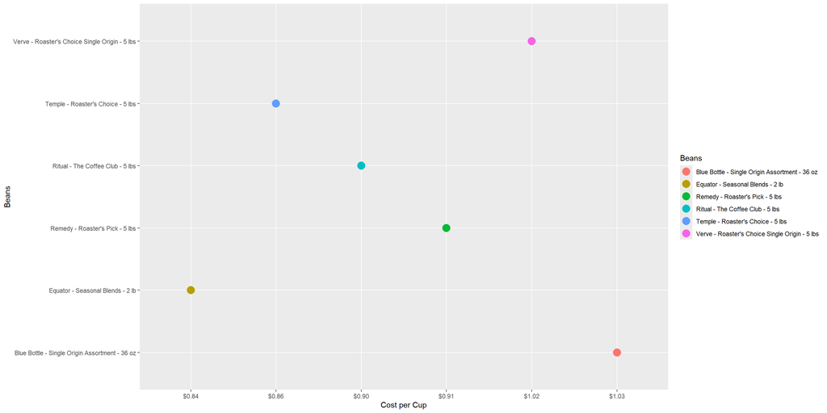

```r
ggplot(data = NorCalCoffee)+
  geom_point(mapping = aes(x=`Cost per Cup`, y=`Beans`, color=`Beans`), size=5)
```

## More Cleaning and Manuipulation With A Plot

Here I loaded stringr first since I wanted to change 36 oz to 2.25 lbs so it would match the format of the rest of the Beans. I did this using a pipe to change from cheap_coffee to NorCalCoffee. I then added a second pipe to get the change I had made into the label Beans and titled the change CalCoffee. Then I used CalCoffee to make changes to the x-axis label and to join both $ per cup and $ per pound of coffee. Last, I plotted my changes to check my work.

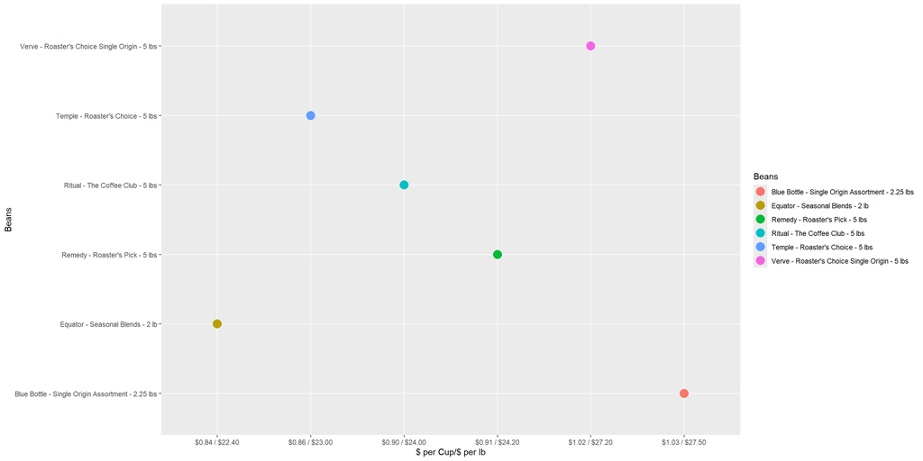

```r
library(stringr)
NorCalCoffee <- cheap_coffee %>%
  mutate(`Bag Size` = str_replace(`Bag Size`, "36 oz", "2.25 lbs"))

CalCoffee <- NorCalCoffee %>%
  mutate(Beans = paste(`Coffee Company`, `Subscription Model`, `Bag Size`, sep = " - "))

CalCoffee <- CalCoffee %>%
  mutate(`$ per Cup/$ per lb` = paste(`Cost per Cup`, `Price per lb`, sep = " / "))

ggplot(data = CalCoffee) +
  geom_point(mapping = aes(x = `$ per Cup/$ per lb`, y = `Beans`, color = `Beans`), size = 5)
```

## Reordering Data in Plot

Here I am reordering the data that is in CalCoffee, so it will show in descending order when plotted. I renamed the data CalCoffee1 so I could distinguish between the changes I am making to my data. Next, I plotted to check my work again, I added “stat = identity” to tell ggplot to use the actual values to plot for the y-axis. I also used “geom_bar” to change from a scatter plot to a bar graph. So, I added “coord_flip()” to flip the bars of the bar graph from vertical to horizontal, matching the labels for the x and y axes.

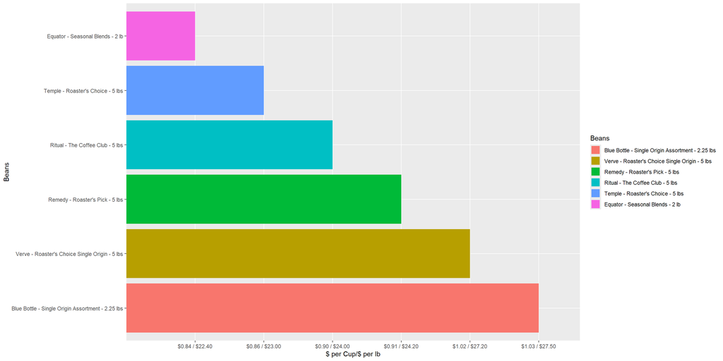

```r
CalCoffee1 <- CalCoffee %>%
  mutate(Beans = fct_reorder(`Beans`, `$ per Cup/$ per lb`, .desc = TRUE))

ggplot(data = CalCoffee1) +
  geom_bar(mapping = aes(x = Beans, y = `$ per Cup/$ per lb`, fill = Beans), stat = "identity", size = 5) +
  coord_flip()
```